# Assignment 1 - Classification

Bevor mit der Klassifikation begonnen wird, werden zunächst die Daten importiert.

```python
# Python ≥3.5 is required
import sys
assert sys.version_info >= (3, 5)



import sklearn
assert sklearn.__version__ >= "0.20"


import pandas as pd
import numpy as np
import os
import warnings
warnings.filterwarnings('ignore')

np.random.seed(42)


%matplotlib inline
import matplotlib as mpl
import matplotlib.pyplot as plt
mpl.rc('axes', labelsize=14)
mpl.rc('xtick', labelsize=12)
mpl.rc('ytick', labelsize=12)


PROJECT_ROOT_DIR = "."
CHAPTER_ID = "classifcation"
IMAGES_PATH = os.path.join(PROJECT_ROOT_DIR, "images", CHAPTER_ID)
os.makedirs(IMAGES_PATH, exist_ok=True)

def save_fig(fig_id, tight_layout=True, fig_extension="png", resolution=300):
    path = os.path.join(IMAGES_PATH, fig_id + "." + fig_extension)
    print("Saving figure", fig_id)
    if tight_layout:
        plt.tight_layout()
    plt.savefig(path, format=fig_extension, dpi=resolution)
```

## Aufgabe 1

```python
fintech_data = pd.read_csv("01_FinTech_Churn.csv", sep=';')

fintech_data.info()
```

```
<class 'pandas.core.frame.DataFrame'>
RangeIndex: 10000 entries, 0 to 9999
Data columns (total 11 columns):
 #   Column            Non-Null Count  Dtype
---  ------            --------------  -----
 0   CCreditScore      10000 non-null  int64
 1   CGeography        10000 non-null  object
 2   CGender           10000 non-null  object
 3   CAge              10000 non-null  int64
 4   CTenure           10000 non-null  int64
 5   CBalance          10000 non-null  float64
 6   CNumOfProducts    10000 non-null  int64
 7   CHasCrCard        10000 non-null  int64
 8   CIsActiveMember   10000 non-null  int64
 9   CEstimatedSalary  10000 non-null  object
 10  Churn             10000 non-null  int64
dtypes: float64(1), int64(7), object(3)
memory usage: 859.5+ KB
```

```python
from sklearn.preprocessing import LabelEncoder

fintech_data_updated = pd.get_dummies(fintech_data, columns = ['CGender'])
fintech_data_updated_2 = pd.get_dummies(fintech_data_updated, columns = ['CGeography'])

fintech_data_updated_2.head()
```

|  | CCreditScore | CAge | CTenure | CBalance | CNumOfProducts | CHasCrCard | CIsActiveMember | CEstimatedSalary | Churn | CGender_Female | CGender_Male | CGeography_France | CGeography_Germany | CGeography_Spain |
| --- | --- | --- | --- | --- | --- | --- | --- | --- | --- | --- | --- | --- | --- | --- |
| 0 | 619 | 42 | 2 | 0.00 | 1 | 1 | 1 | 101348.88 | 1 | 1 | 0 | 1 | 0 | 0 |
| 1 | 608 | 41 | 1 | 83807.86 | 1 | 0 | 1 | 112542.58 | 0 | 1 | 0 | 0 | 0 | 1 |
| 2 | 502 | 42 | 8 | 159660.80 | 3 | 1 | 0 | 113931.57 | 1 | 1 | 0 | 1 | 0 | 0 |
| 3 | 699 | 39 | 1 | 0.00 | 2 | 0 | 0 | 93826.63 | 0 | 1 | 0 | 1 | 0 | 0 |
| 4 | 850 | 43 | 2 | 125510.82 | 1 | 1 | 1 | 79084.1 | 0 | 1 | 0 | 0 | 0 | 1 |

Hierdurch werden weitere Spalten für jede Kategorie von Geschlecht und Geografie erstellt. Wenn das Merkmal zutrifft, ist eine 1 in der Spalte, wenn nicht eine 0.

Danach wird der Datensatz aufgeteilt, in den Teil, der die Merkmale enthält, und den anderen Teil, der die Zielvariable enthält.

#### Aufteilen des Datsets

```python
feature_set = ['CCreditScore', 'CAge', 'CTenure', 'CBalance' ,'CNumOfProducts', 'CHasCrCard',  'CIsActiveMember', 'CGender_Female', 'CGender_Male', 'CGeography_France', 'CGeography_Germany', 'CGeography_Spain']
X = fintech_data_updated_2[feature_set]
y = fintech_data_updated_2.Churn
```

### Decision Tree

Als nächstes wird der Datensatz mit Hilfe der Methode train_test_split in ein Traings- und ein Testset aufgeteilt.

```python
from sklearn.model_selection import train_test_split
X_train,X_test, y_train, y_test = train_test_split(X, y, test_size=0.3, random_state=42)
```

Danach wird das Tree Model mit der Funktion DecisonTreeClassifier trainert.

```python
# Import Decision Tree model
from sklearn.tree import DecisionTreeClassifier
# Create a Decision Tree classifier object
clf_tree = DecisionTreeClassifier(random_state=42, min_samples_leaf = 0.04)

# Train the model using training dataset
clf_tree = clf_tree.fit(X_train,y_train)
```

#### Visualisierung des Datensets

Um den Baum evaluieren zu können, wird er nun visuell dargestellt.

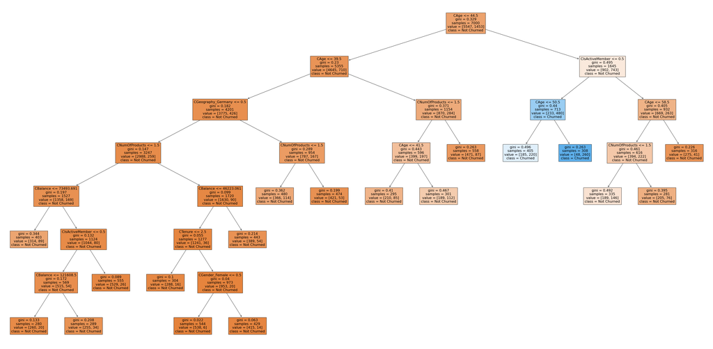

```python
import matplotlib.pyplot as plt
from sklearn import tree
plt.figure(figsize=(60,30))  # customize according to the size of your tree
_ = tree.plot_tree(clf_tree,feature_names = X_train.columns, filled=True, class_names= ["Not Churned","Churned"])
plt.show()
```

#### Confusion matrix training data

Als nächstes wird die Konfusionsmatrix ausgegeben, in welcher sichtbar wird, wie viele False und True Positives und False und True Negatives es gibt - also welche Entscheidungen des Entscheidungsbaums basierend auf dem Trainings- und Testdatensatz richtig getroffen wurden.

```
<sklearn.metrics._plot.confusion_matrix.ConfusionMatrixDisplay at 0x7fbcb24d5af0>
```

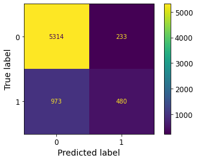

```python
# Import the confusion matrix
from sklearn.metrics import plot_confusion_matrix

# Plot Confusion matrix
plot_confusion_matrix(clf_tree , X_train, y_train, values_format='d')
```

```python
import numpy as np
# Predict the response for training dataset
y_pred_train = clf_tree.predict(X_train)
np.sum(np.equal(y_train, y_pred_train)) / len(y_train)
```

```
0.8277142857142857
```

#### Classifier Evaluation

```
<sklearn.metrics._plot.confusion_matrix.ConfusionMatrixDisplay at 0x7fbcd8ed6340>
```

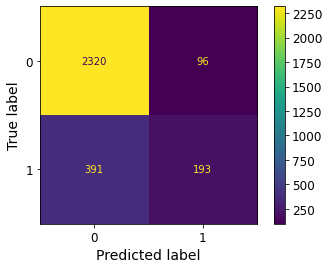

```python
 # Predict the response for test dataset
y_pred_test = clf_tree.predict(X_test)

# Import the confusion matrix
from sklearn.metrics import plot_confusion_matrix

# Plot Confusion matrix
plot_confusion_matrix(clf_tree , X_test, y_test, values_format='d')
```

Performance Metrics

```python
# Import metrics module for performance evaluation
from sklearn.metrics import accuracy_score
from sklearn.metrics import precision_score
from sklearn.metrics import recall_score
from sklearn.metrics import f1_score
# Calculate model accuracy
print("Accuracy:",accuracy_score(y_test, y_pred_test))
# Calculate model precision
print("Precision:",precision_score(y_test, y_pred_test))
# Calculate model recall
print("Recall:",recall_score(y_test, y_pred_test))
# Calculate model f1 score
print("F1-Score:",f1_score(y_test, y_pred_test))
```

```
Accuracy: 0.8376666666666667
Precision: 0.6678200692041523
Recall: 0.3304794520547945
F1-Score: 0.4421534936998855
```

Die Rate an richtigen Entscheidungen (Accuracy) des Decision Trees ist mit 0.83 relativ hoch, jedoch sind die Werte für die Fähigkeit Positive Werte zu erkennen (Recall), mit 0,33 relativ niedrig. Auch der Wert an positiven Werten, von denen, die Positiv gewertet wurden, ist niedrig. Das Modell kann also gut aussagen, wenn ein Kunde die Bank nicht verlässt - aber nicht so gut, wenn er sie verlässt.

### K-nearest neighbors

Als nächstes wird das K nearest Neigbors Model angewandt. Dafür werden zunächst die Daten aufbereitet, d.h. in diesem Fall die einzelnen Werte zu skalieren, sodass sie vergleichbar werden.

```python
from sklearn.preprocessing import StandardScaler
# scale the data
scaler = StandardScaler()
scaler.fit(X)
X_scaled = scaler.transform(X)
pd.DataFrame(X_scaled)
```

|  | 0 | 1 | 2 | 3 | 4 | 5 | 6 | 7 | 8 | 9 | 10 | 11 |
| --- | --- | --- | --- | --- | --- | --- | --- | --- | --- | --- | --- | --- |
| 0 | -0.326221 | 0.293517 | -1.041760 | -1.225848 | -0.911583 | 0.646092 | 0.970243 | 1.095988 | -1.095988 | 0.997204 | -0.578736 | -0.573809 |
| 1 | -0.440036 | 0.198164 | -1.387538 | 0.117350 | -0.911583 | -1.547768 | 0.970243 | 1.095988 | -1.095988 | -1.002804 | -0.578736 | 1.742740 |
| 2 | -1.536794 | 0.293517 | 1.032908 | 1.333053 | 2.527057 | 0.646092 | -1.030670 | 1.095988 | -1.095988 | 0.997204 | -0.578736 | -0.573809 |
| 3 | 0.501521 | 0.007457 | -1.387538 | -1.225848 | 0.807737 | -1.547768 | -1.030670 | 1.095988 | -1.095988 | 0.997204 | -0.578736 | -0.573809 |
| 4 | 2.063884 | 0.388871 | -1.041760 | 0.785728 | -0.911583 | 0.646092 | 0.970243 | 1.095988 | -1.095988 | -1.002804 | -0.578736 | 1.742740 |
| ... | ... | ... | ... | ... | ... | ... | ... | ... | ... | ... | ... | ... |
| 9995 | 1.246488 | 0.007457 | -0.004426 | -1.225848 | 0.807737 | 0.646092 | -1.030670 | -0.912419 | 0.912419 | 0.997204 | -0.578736 | -0.573809 |
| 9996 | -1.391939 | -0.373958 | 1.724464 | -0.306379 | -0.911583 | 0.646092 | 0.970243 | -0.912419 | 0.912419 | 0.997204 | -0.578736 | -0.573809 |
| 9997 | 0.604988 | -0.278604 | 0.687130 | -1.225848 | -0.911583 | -1.547768 | 0.970243 | 1.095988 | -1.095988 | 0.997204 | -0.578736 | -0.573809 |
| 9998 | 1.256835 | 0.293517 | -0.695982 | -0.022608 | 0.807737 | 0.646092 | -1.030670 | -0.912419 | 0.912419 | -1.002804 | 1.727904 | -0.573809 |
| 9999 | 1.463771 | -1.041433 | -0.350204 | 0.859965 | -0.911583 | 0.646092 | -1.030670 | 1.095988 | -1.095988 | 0.997204 | -0.578736 | -0.573809 |

10000 rows × 12 columns

Danach wird der Datensatz wieder in einen Trainings- und einen Testdatensatz aufgeteilt.

```python
# Partition data into training and testing set
from sklearn.model_selection import train_test_split
X_train_scaled,X_test_scaled, y_train_scaled, y_test_scaled = train_test_split(X_scaled, y, test_size=0.3, random_state=42)
```

Als Nächstes wird das knn Model trainert, mit der Funktion KNeighborsClassifier.

```python
from sklearn.neighbors import KNeighborsClassifier

# Create a KNN classifier object
clf_kNN = KNeighborsClassifier(n_neighbors=3)

# Train the model using the training dataset
clf_kNN.fit(X_train_scaled,y_train_scaled)
```

```
KNeighborsClassifier(n_neighbors=3)
```

Danach werden die Entscheidungswerte evaluiert.

```python
# Predict the y variable for train dataset
y_pred_train_knn = clf_kNN.predict(X_train_scaled)

# Import metrics module for performance evaluation
from sklearn.metrics import accuracy_score
from sklearn.metrics import precision_score
from sklearn.metrics import recall_score
from sklearn.metrics import f1_score

# Calculate model accuracy
print("Accuracy:",accuracy_score(y_train_scaled, y_pred_train_knn))
# Calculate model precision
print("Precision:",precision_score(y_train_scaled, y_pred_train_knn))
# Calculate model recall
print("Recall:",recall_score(y_train_scaled, y_pred_train_knn))
# Calculate model f1 score
print("F1-Score:",f1_score(y_train_scaled, y_pred_train_knn))
```

```
Accuracy: 0.9007142857142857
Precision: 0.8272884283246977
Recall: 0.6593255333792154
F1-Score: 0.7338184603600153
```

```python
# Predict the y variable for test dataset
y_pred_test_knn = clf_kNN.predict(X_test_scaled)

# Import metrics module for performance evaluation
from sklearn.metrics import accuracy_score
from sklearn.metrics import precision_score
from sklearn.metrics import recall_score
from sklearn.metrics import f1_score

# Calculate model accuracy
print("Accuracy:",accuracy_score(y_test, y_pred_test_knn))
# Calculate model precision
print("Precision:",precision_score(y_test, y_pred_test_knn))
# Calculate model recall
print("Recall:",recall_score(y_test, y_pred_test_knn))
# Calculate model f1 score
print("F1-Score:",f1_score(y_test, y_pred_test_knn))
```

```
Accuracy: 0.8403333333333334
Precision: 0.6212471131639723
Recall: 0.4606164383561644
F1-Score: 0.5290068829891839
```

Aus der Auswertung lässt sich ablesen, dass das Trainingsmodell besser abschneidet als das Test-Datenset. Hierbei ist die Accuracy noch relativ hoch, jedoch sind Precision und Recall niederiger. Auch der F1 Score ist nicht besonders hoch. Das heißt, das Modell kann viel korrekte Vorhersagen machen, jedoch ist der Wert an wirklich positiven niedriger und auch die Fähigkeit Kunden zu erkennen, die gehen, ist nicht so hoch.

```python
accuracy = []

# Calculating error for K values between 1 and 40
for i in range(1, 40):
    knn = KNeighborsClassifier(n_neighbors=i)
    knn.fit(X_train_scaled, y_train_scaled)
    pred_i = knn.predict(X_test_scaled)
    accuracy.append(accuracy_score(y_test_scaled, pred_i))
```

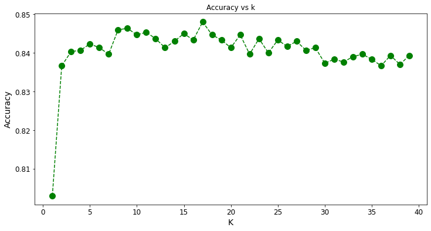

```python
import matplotlib.pyplot as plt

plt.figure(figsize=(12, 6))
plt.plot(range(1, 40), accuracy, color='green', linestyle='dashed', marker='o',
         markerfacecolor='green', markersize=10)
plt.title('Accuracy vs k')
plt.xlabel('K')
plt.ylabel('Accuracy')
```

An der Grafik lässt sich sehen, dass mit der Auswahl von 3 als n_neigbor Werte, ein guter Punkt für die Accuracy gewählt wurde. Zwar könnte sich eine noch höhrere Accurcy bei einem Wert von ca. 8 finden, aber umso höher das n umso höher könnte auch der Bias werden. Mit einem niedrigeren n entsteht ein komplexeres Model, was zu Overfitting führen kann. Bei einem höhren n entsteht eine glattere Entscheidungsgrenze, aber auch ein weniger komplexes Modell.

### Naive Bayes

Für das Naive Bayes Model werden zunächst die Daten wieder in einem Trainings- und ein Testdatenset aufgeteilt.

```python
# Partition data into training and testing set
from sklearn.model_selection import train_test_split
X_train,X_test, y_train, y_test = train_test_split(X, y, test_size=0.3, random_state=42)
```

Danach wird das Model trainiert.

```python
# Import Gaussian Naive Bayes model
from sklearn.naive_bayes import GaussianNB

# Create a Gaussian Classifier
clf_gnb = GaussianNB()

# Train the model using the training sets
clf_gnb.fit(X_train,y_train)
```

```
GaussianNB()
```

Als nächstes werden die Trainings- und Testdaten wieder evaluiert.

```python
# Predict the y variable for the test dataset
y_pred_train_gnb = clf_gnb.predict(X_train)

# Import metrics module for performance evaluation
from sklearn.metrics import accuracy_score
from sklearn.metrics import precision_score
from sklearn.metrics import recall_score
from sklearn.metrics import f1_score

# Calculate model accuracy
print("Accuracy:",accuracy_score(y_train, y_pred_train_gnb))
# Calculate model precision
print("Precision:",precision_score(y_train, y_pred_train_gnb))
# Calculate model recall
print("Recall:",recall_score(y_train, y_pred_train_gnb))
# Calculate model f1 score
print("F1-Score:",f1_score(y_train, y_pred_train_gnb))
```

```
Accuracy: 0.7821428571428571
Precision: 0.3875
Recall: 0.08534067446662079
F1-Score: 0.1398759165256627
```

```python
# Predict the y variable for the test dataset
y_pred_test_gnb = clf_gnb.predict(X_test)

# Import metrics module for performance evaluation
from sklearn.metrics import accuracy_score
from sklearn.metrics import precision_score
from sklearn.metrics import recall_score
from sklearn.metrics import f1_score

# Calculate model accuracy
print("Accuracy:",accuracy_score(y_test, y_pred_test_gnb))
# Calculate model precision
print("Precision:",precision_score(y_test, y_pred_test_gnb))
# Calculate model recall
print("Recall:",recall_score(y_test, y_pred_test_gnb))
# Calculate model f1 score
print("F1-Score:",f1_score(y_test, y_pred_test_gnb))
```

```
Accuracy: 0.7943333333333333
Precision: 0.368
Recall: 0.07876712328767123
F1-Score: 0.12976022566995768
```

Die Accuracy ist hoch, jedoch ist die Precision sehr niedrig, d.h. die Anzahl an wirklich Positiven in der Zuordnung an Positiven ist niedrig - wodurch auch der F1-Score niedrig wird.

## Advanced Classifier Evaluation

Dafür werden für jeden der verwendeten Machine Learning Modelle die ROC Kurve berechnet und dargestellt. Danach wird der AUC (Area under the Curve) berechnet, um die Modelle tiefergehend zu evaluieren.

### ROC and AUC (Decicion Tree)

```
<sklearn.metrics._plot.roc_curve.RocCurveDisplay at 0x7fbcb24d53a0>
```

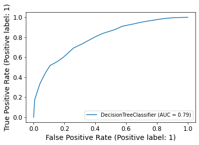

```python
# import plot_roc_curve
from sklearn.metrics import plot_roc_curve

plot_roc_curve(clf_tree , X_test, y_test)
```

```python
# import ROC AUC score
from sklearn.metrics import roc_auc_score

# Compute the area under ROC curve
auc = roc_auc_score(y_test, y_pred_test)

# Print auc value
print("Area Under Curve:",auc)
```

```
Area Under Curve: 0.6453721763585231
```

### ROC and AUC (kNN)

```
<sklearn.metrics._plot.roc_curve.RocCurveDisplay at 0x7fbcc03fbe20>
```

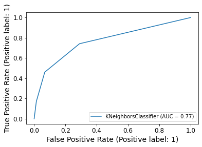

```python
# import plot_roc_curve
from sklearn.metrics import plot_roc_curve
plot_roc_curve(clf_kNN , X_test_scaled, y_test_scaled)
```

```python
# import ROC AUC score
from sklearn.metrics import roc_auc_score

# Compute the area under ROC curve
auc = roc_auc_score(y_test_scaled, y_pred_test_knn)

# Print auc value
print("Area Under Curve:",auc)
```

```
Area Under Curve: 0.6963678218270889
```

### ROC and AUC (GNB)

```
<sklearn.metrics._plot.roc_curve.RocCurveDisplay at 0x7fbcd0b41d00>
```

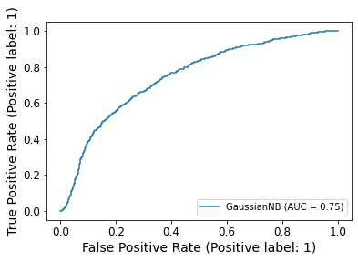

```python
# import plot_roc_curve
from sklearn.metrics import plot_roc_curve
plot_roc_curve(clf_gnb , X_test, y_test)
```

```python
# import ROC AUC score
from sklearn.metrics import roc_auc_score

# Compute the area under ROC curve
auc = roc_auc_score(y_test, y_pred_test_gnb)

# Print auc value
print("Area Under Curve:",auc)
```

```
Area Under Curve: 0.5230342238954913
```

### ROC and AUC (all Classifier)

Zuletzt werden zum besseren Vergleich alle Klassifizierungs-Modelle zusammen in einer Grafik dargestellt.

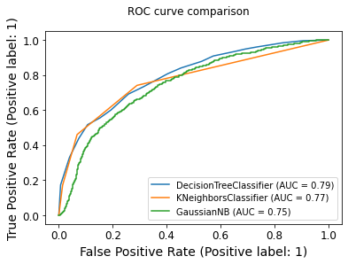

```python
fig = plot_roc_curve(clf_tree , X_test, y_test)
fig = plot_roc_curve(clf_kNN , X_test_scaled, y_test_scaled, ax = fig.ax_)
fig = plot_roc_curve(clf_gnb, X_test, y_test,ax = fig.ax_)
fig.figure_.suptitle("ROC curve comparison")
plt.show()
```

## Aufgabe 2

Um die Methode noch weiter zu optimieren, werden erweiterte Konzepte angewendet. Dafür werden zunächst die Daten auf Unausgewogenheiten überprüft, das bedeutet, ob das Ergebnis, ob ein Kunde abgewandert ist, gleichmäßig verteilt vorkommt, oder ob es eine Unausgewogenheit in einer Richtung gibt.

```python
y.value_counts()
```

```
0    7963
1    2037
Name: Churn, dtype: int64
```

Aus dem Ergebnis wird ersichtlich, dass es mehr Datensätze zu Kunden gibt, die nicht abgewandert sind, als welche, die abgewandert sind. Nun gibt es zwei Methoden, die angewendet werden könnten. Zum einen Undersampling, d.h. die Datensätze, die zu viel vorhanden sind, werden entfernt oder zum anderen Oversampling, bei welchem Klone der unterrepräsentierten Kategorie hinzugefügt werden. In diesem Fall wird Synthetisches Oversampling angewendet, welches k-nearest neighbors verwendet, um die unterrepräsentierten Datensätze zu klonen.

### Oversampling

```python
from imblearn.over_sampling import RandomOverSampler
from imblearn.under_sampling import RandomUnderSampler
from imblearn.over_sampling import SMOTE

ros = RandomOverSampler(random_state=0)

X_oversampled, y_ovesampled = SMOTE().fit_resample(X, y)
```

```python
y_ovesampled.value_counts()
```

```
1    7963
0    7963
Name: Churn, dtype: int64
```

Nun ist zu sehen, dass von jedem Ausgang gleich viele Datensätze vorhanden sind.

Als nächstes werden die Daten wieder in ein Trainings- und ein Testset aufgeteilt und der neue Entscheidungsbaum trainiert.

```python
X_train_OS,X_test_OS, y_train_OS, y_test_OS = train_test_split(X_oversampled, y_ovesampled, test_size=0.3, random_state=42)
```

```python
# Create a Decision Tree classifier object
clf_tree_OS = DecisionTreeClassifier(random_state=42, min_samples_leaf = 0.04)

# Train the model using training dataset
clf_tree_OS = clf_tree_OS.fit(X_train_OS,y_train_OS)
```

Zur Evaluation wird erneut eine Konfusionsmatrix erstellt.

```
<sklearn.metrics._plot.confusion_matrix.ConfusionMatrixDisplay at 0x7fbca083cb20>
```

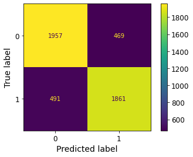

```python
# Predict the response for test dataset
y_pred_test_OS = clf_tree_OS.predict(X_test_OS)

# Plot Confusion matrix
plot_confusion_matrix(clf_tree_OS , X_test_OS, y_test_OS, values_format='d')
```

```python
# Calculate model accuracy
print("Accuracy:",accuracy_score(y_test_OS, y_pred_test_OS))
```

```
Accuracy: 0.799079112599414
```

```python
# Calculate model accuracy
print("Accuracy:",accuracy_score(y_test_OS, y_pred_test_OS))
# Calculate model precision
print("Precision:",precision_score(y_test_OS, y_pred_test_OS))
# Calculate model recall
print("Recall:",recall_score(y_test_OS, y_pred_test_OS))
# Calculate model f1 score
print("F1-Score:",f1_score(y_test_OS, y_pred_test_OS))
```

```
Accuracy: 0.799079112599414
Precision: 0.7987124463519313
Recall: 0.7912414965986394
F1-Score: 0.7949594190516872
```

Die Accuracy ist durch das Oversampling geringer geworden, jedoch sind die anderen Werte nun auf einem wesentlich höheren Niveau. Da Accuracy sich auf die Gesamtzahl der Vorhersagen bezieht und nicht auch die Verteilung der Fehler berücksichtigt, kann es von Vorteil sein, wenn alle Werte ein besseres Niveau haben.

### Cross-Validation

Als nächstes wird Cross Valdiation angewandt, da diese Methode stabiler und gründlicher ist als die Aufteilung in einen Trainings- und einen Testsatz. Bei der Cross-Validiation werden die Daten stattdessen wiederholt aufgeteilt, und es werden mehrere Modelle trainiert.

```python
from sklearn.model_selection import cross_val_score
scores = cross_val_score(clf_tree_OS, X_train_OS,y_train_OS, scoring='accuracy')
print("Cross-validation scores: {}".format(scores))
print("Average cross-validation score: {:.2f}".format(scores.mean()))
print("Standard deviation: {:.2f}".format(scores.std()))
```

```
Cross-validation scores: [0.79282511 0.76860987 0.80538117 0.78869448 0.78375953]
Average cross-validation score: 0.79
Standard deviation: 0.01
```

```python
#accuracy scores
y_pred_train_OS = clf_tree_OS.predict(X_train_OS)

print("Accuracy of training data:",accuracy_score(y_train_OS, y_pred_train_OS))
print("Accuracy of test data:",accuracy_score(y_test_OS, y_pred_test_OS))
print("Accuracy of cross-validation:", cross_val_score(clf_tree_OS, X_train_OS,y_train_OS,scoring='accuracy').mean())
```

```
Accuracy of training data: 0.7983494797273053
Accuracy of test data: 0.799079112599414
Accuracy of cross-validation: 0.7878540317502469
```

Generell würde ich das Modell aus Aufgabe 2 bevorzugen - zwar ist die Accuracy niedriger, jedoch sind die anderen Werte besser als zuvor denn die Precision beschreibt, wie viele der von einem Modell als positiv klassifizierten Fälle tatsächlich positiv sind, d.h. ein hoher Precision-Wert bedeutet, dass das Modell selektiv vorhersagt und weniger falsch positive Vorhersagen liefert. Der Recall beschreibt, wie viele der tatsächlich positiven Fälle das Modell als positiv klassifiziert. Ein hoher Recall-Wert bedeutet, dass das Modell in der Lage ist, die meisten positiven Fälle zu erkennen. Dies ist, wenn hier wirklich Entscheidungen über Kunden getroffen werden, wichtiger und deswegen entscheidener als die Accuracy. Denn Accuracy allein ist nicht immer ein zuverlässiger Indikator für die Qualität eines Modells, da es sich auf die Gesamtzahl der Vorhersagen bezieht und nicht die Verteilung der Fehler berücksichtigt.